# exercise_05_challenge_2

SLCornett

2/24/2022

```r
library(tidyverse)
```

```r
library(mosaic)
library(dplyr)
library(ggplot2)
library(radiant)
library(cowplot)
```

1. Using the {tidyverse} read_csv() function, load the “zombies.csv” dataset from this URL as a “tibble” named z. This dataset includes the first and last name and gender of the entire population of 1000 people who have survived the zombie apocalypse and are now ekeing out an existence somewhere on the Gulf Coast, along with several other variables (height, weight, age, number of years of education, number of zombies they have killed, and college major)

```r
f2<- "https://raw.githubusercontent.com/difiore/ada-2022-datasets/main/zombies.csv"
z <- read_csv(f2, col_names = TRUE)
z #show me the tibble! hello, Tony, where are the nonbinary survivors?
```

```
## # A tibble: 1,000 × 10
##       id first_name last_name gender height weight zombies_killed
##    <dbl> <chr>      <chr>     <chr>   <dbl>  <dbl>          <dbl>
##  1     1 Sarah      Little    Female   62.9   132.              2
##  2     2 Mark       Duncan    Male     67.8   146.              5
##  3     3 Brandon    Perez     Male     72.1   153.              1
##  4     4 Roger      Coleman   Male     66.8   130.              5
##  5     5 Tammy      Powell    Female   64.7   132.              4
##  6     6 Anthony    Green     Male     71.2   153.              1
##  7     7 Theresa    Hamilton  Female   70.3   160.              0
##  8     8 Phyllis    Jenkins   Female   59.8   109.              4
##  9     9 Steven     Long      Male     68.6   153.              9
## 10    10 Russell    Chavez    Male     72.8   169.              2
## # … with 990 more rows, and 3 more variables: years_of_education <dbl>,
## #   major <chr>, age <dbl>
```

2. Calculate the population mean and standard deviation for each quantitative (numbers) random variable in the dataset (height, weight, age, number of zombies killed, and years of education).

```r
zp_mean <- summarize(z,
                       mean(height),
                       mean(weight),
                       mean(age),
                       mean(zombies_killed),
                       mean(years_of_education)
                       )
print(zp_mean)
```

```
## # A tibble: 1 × 5
##   `mean(height)` `mean(weight)` `mean(age)` `mean(zombies_kil…` `mean(years_of…`
##            <dbl>          <dbl>       <dbl>               <dbl>            <dbl>
## 1           67.6           144.        20.0                2.99             3.00
```

```r
zp_sd <- summarize(z,
                   sdpop(height),
                   sdpop(weight),
                   sdpop(age),
                   sdpop(zombies_killed),
                   sdpop(years_of_education)
                   )
print(zp_sd)
```

```
## # A tibble: 1 × 5
##   `sdpop(height)` `sdpop(weight)` `sdpop(age)` `sdpop(zombies…` `sdpop(years_o…`
##             <dbl>           <dbl>        <dbl>            <dbl>            <dbl>
## 1            4.31            18.4         2.96             1.75             1.68
```

3. Use {ggplot} and make boxplots of each of these variables by gender. 1 = height, 2 = weight, 3 = age, 4 = zombies killed, 5 = years of educadtion

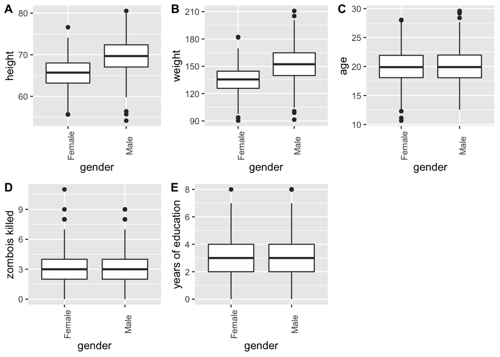

```r
library(cowplot)

#1 gender vs height
zb1 <- ggplot(data=z, aes(x=gender, y = height))
zb1 <- zb1 + geom_boxplot(na.rm = TRUE)
zb1 <- zb1 + theme(axis.text.x=element_text(angle=90))
zb1 <- zb1 + xlab("gender") + ylab("height")

#2 gender vs weight
zb2 <- ggplot(data=z, aes(x=gender, y=weight))
zb2 <- zb2 + geom_boxplot(na.rm = TRUE)
zb2 <- zb2 + theme(axis.text.x=element_text(angle=90))
zb2 <- zb2 + xlab("gender") + ylab("weight")

#3 gender vs age
zb3 <- ggplot(data=z, aes(x=gender, y=age))
zb3 <- zb3 + geom_boxplot(na.rm = TRUE)
zb3 <- zb3 + theme(axis.text.x=element_text(angle=90))
zb3 <- zb3 + xlab("gender") + ylab("age")

#4 gender vs zombois killed
zb4 <- ggplot(data=z, aes(x=gender, y=zombies_killed))
zb4 <- zb4 + geom_boxplot(na.rm = TRUE)
zb4 <- zb4 + theme(axis.text.x=element_text(angle=90))
zb4 <- zb4 + xlab("gender") + ylab("zombois killed")

#5 gender vs years of education
zb5 <- ggplot(data=z, aes(x=gender, y=years_of_education))
zb5 <- zb5 + geom_boxplot(na.rm = TRUE)
zb5 <- zb5 + theme(axis.text.x=element_text(angle=90))
zb5 <- zb5 + xlab("gender") + ylab("years of education")

#like facet wrap, but cows!
plot_grid(zb1, zb2, zb3, zb4, zb5, labels = c('A', 'B', 'C', 'D', 'E'), label_size = 12, nrow = 2)
```

4. Use {ggplot} and make scatterplots of height and weight in relation to age (i.e., use age as the x variable), using different colored points for males versus females. (mod 9.6)

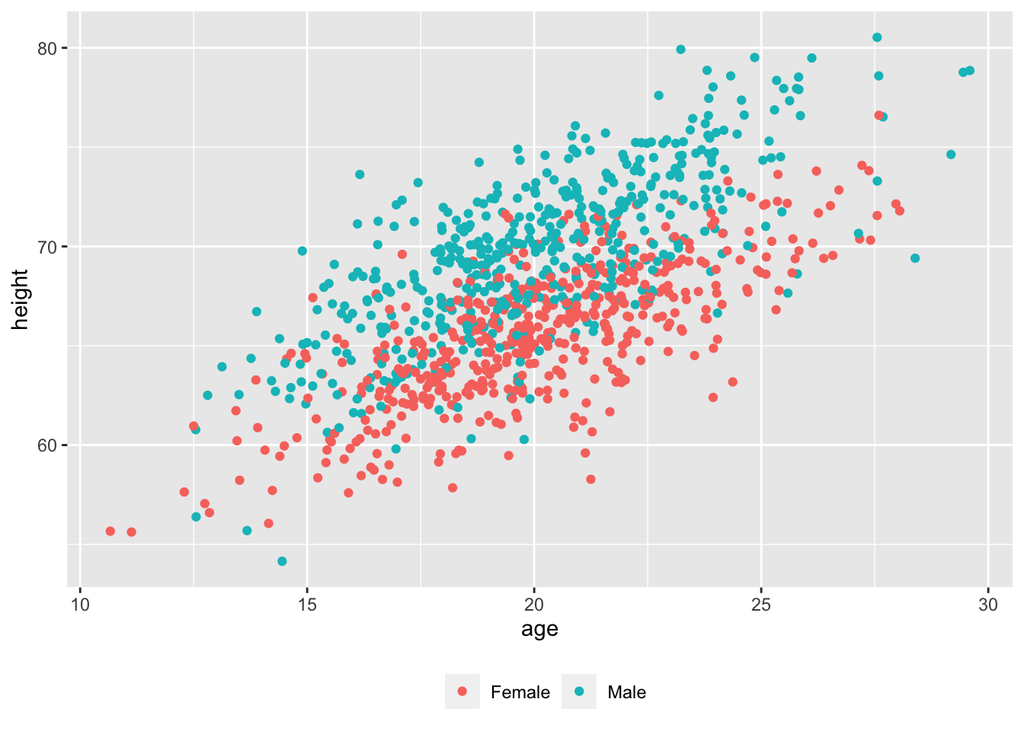

```r
#age vs height
zscat1 <- ggplot(data=z, aes(x=age, y=height, color=factor(gender))) #establish plot
zscat1 <- zscat1 + xlab("age") + ylab("height") #labels
zscat1 <- zscat1 + geom_point(na.rm=TRUE) #makes a scatterplot
zscat1 <- zscat1 + theme(legend.position="bottom", legend.title=element_blank()) #legend location
zscat1
```

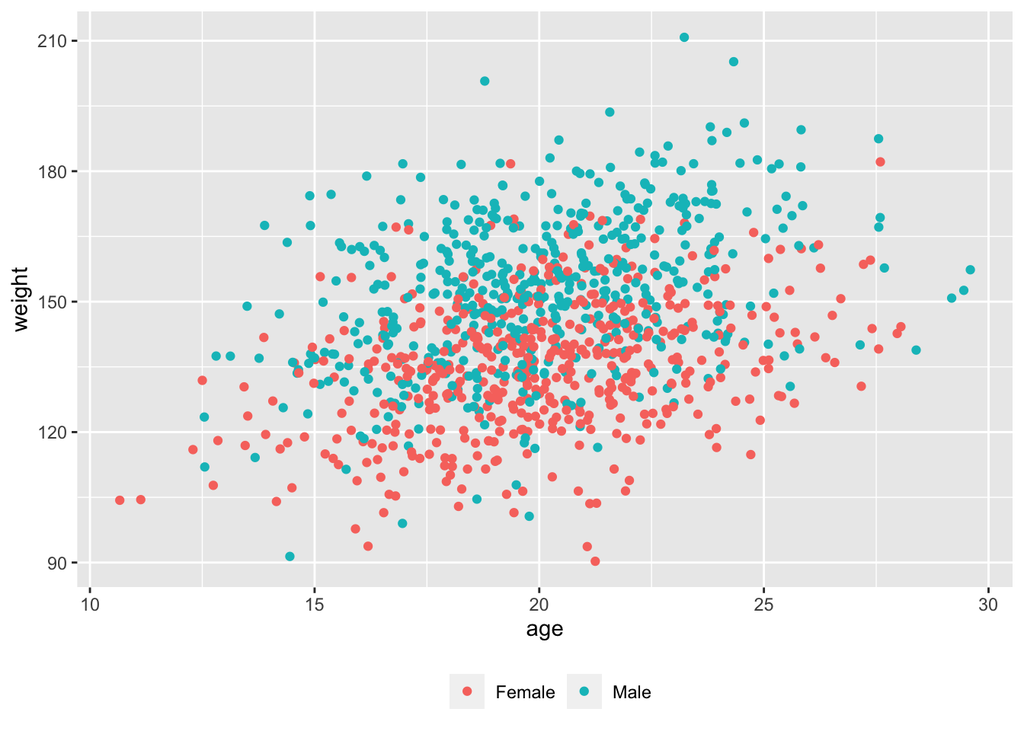

```r
#age vs weight
zscat2 <- ggplot(data=z, aes(x=age, y=weight, color=factor(gender))) #establish plot
zscat2 <- zscat2 + xlab("age") + ylab("weight") #labels
zscat2 <- zscat2 + geom_point(na.rm=TRUE) #makes a scatterplot
zscat2 <- zscat2 + theme(legend.position="bottom", legend.title=element_blank()) #legend location
zscat2
```

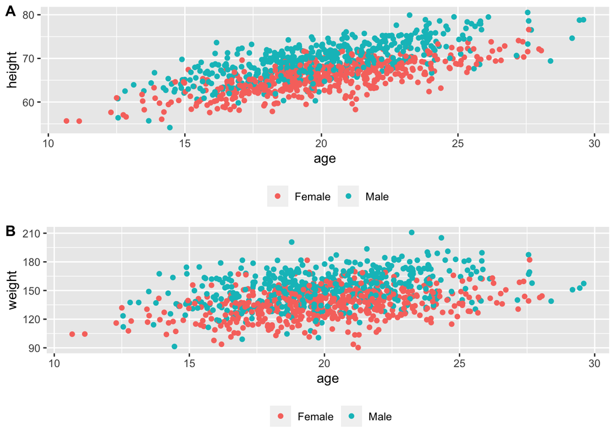

```r
#cowplot again!
plot_grid(zscat1, zscat2, labels = c('A', 'B'), label_size = 12, nrow = 2)
```

Q: Do these variables seem to be related? In what way? A: yes they do, because both weight and height have a linear relationship with age, both are positively correlated.

5. Using histograms and Q-Q plots (quantile-quantile or Q-Q plot), check whether each of the quantitative variables seem to be drawn from a normal distribution. [Q–Q plot is a general graphical method for comparing two probability distributions. To examine a set of data for normality graphically, you plot the quantiles for your actual data (as the y values) versus theoretical quantiles (as the x values) pulled from a normal distribution. If the two distributions being compared are similar, the points in the plot should lie approximately on the line y = x.] 1 = height, 2 = weight, 3 = age, 4 = zombies killed, 5 = years of educadtion

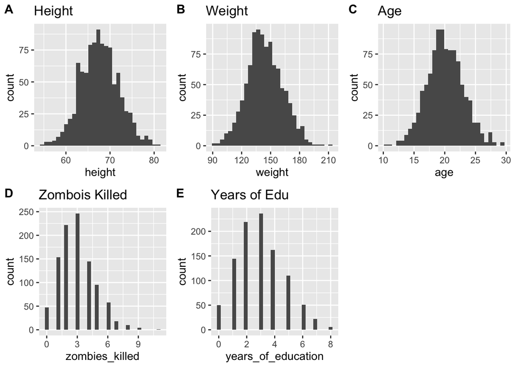

```r
#HISTOGRAM
#1 height
zq1 <- ggplot(data = z) #just the data because r has feelings
zq1<- zq1 + geom_histogram(aes(x=height, binwidth = 30))
zq1<- zq1 + ggtitle("Height")

#2 weight
zq2 <- ggplot(data = z) #just the data because r has feelings
zq2<- zq2 + geom_histogram(aes(x=weight, binwidth = 30))
zq2<- zq2 + ggtitle("Weight")

#3 age
zq3 <- ggplot(data = z) #just the data because r has feelings
zq3<- zq3 + geom_histogram(aes(x=age, binwidth = 30))
zq3<- zq3 + ggtitle("Age")

#4 Zombies Killed
zq4 <- ggplot(data = z) #just the data because r has feelings
zq4<- zq4 + geom_histogram(aes(x=zombies_killed, binwidth = 30))
zq4<- zq4 + ggtitle("Zombois Killed")

#5 Years of Education
zq5 <- ggplot(data = z) #just the data because r has feelings
zq5<- zq5 + geom_histogram(aes(x=years_of_education, binwidth = 30)) #not sure why the bars are so narrow. decreasing the bin size did not help.
zq5<- zq5 + ggtitle("Years of Edu")

#cowplot again! AGAIN!
plot_grid(zq1, zq2, zq3, zq4, zq5, labels = c('A', 'B', 'C', 'D', 'E'), label_size = 12, nrow = 2)
```

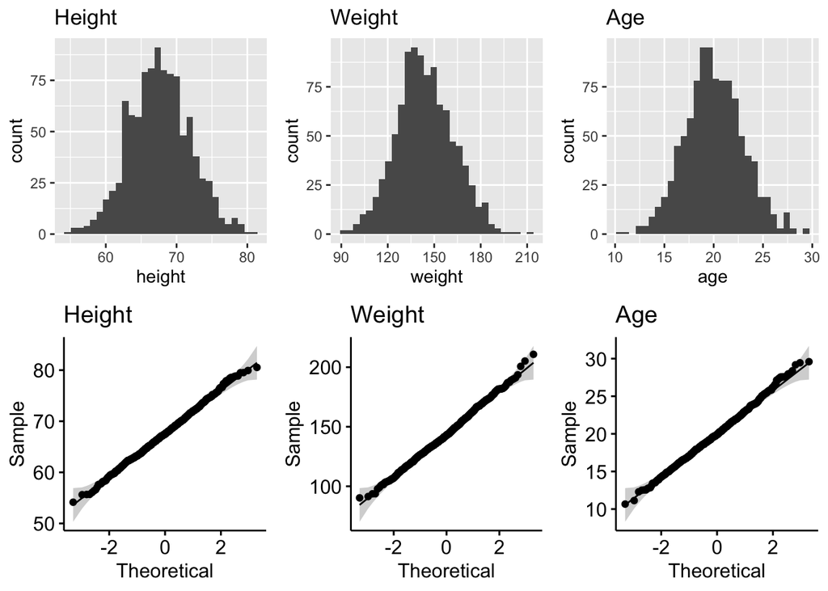

```r
#Q-Q PLOTS
library(car)
library(ggpubr)
#6 height
#zq6<- qqPlot(z$height) #qq_lot, not qqplot. couldn't figure out how tot get qqplot or qqnorm to work. looked at module 9 and 13
zq6<-ggqqplot(z$height, title = "Height") #does the same as qqPlot() but looks nicer? and allows a title

#7 weight
zq7<-ggqqplot(z$weight, title = "Weight")

#8 age
zq8 <-ggqqplot(z$age, title = "Age")

#9 Zombies Killed
zq9 <-ggqqplot(z$zombies_killed, title = "Zombies Killed")

#10 Years of Education
zq10<- ggqqplot(z$years_of_education, title = "Years of Education")

#plotting qq plots and histograms together
plot_grid(zq1, zq2, zq3,zq6, zq7, zq8, label_size = 12, nrow = 2)
```

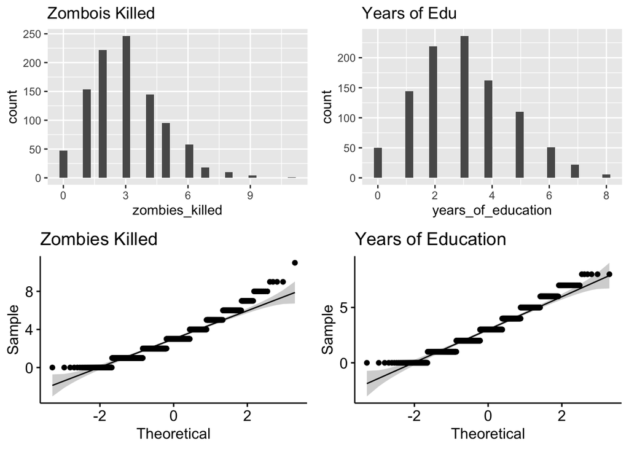

```r
plot_grid(zq4, zq5, zq9, zq10, label_size = 12, nrow = 2)
```

Q: Which seem to be quantitative variables seem to be drawn from a normal distribution, and which do not? A: height, weight, and age seem to be normally distributed. This makes sense because they are linear variables. Zombies killed and years of education are not normally distributed, so must be plotted with something other than a normal distribution.

6. Now use the sample_n() function from {dplyr} to [1] sample ONE subset of 50 zombie apocalypse survivors (without replacement) from this population and [2] calculate the mean and [3] sample standard deviation for each variable. [4] Also estimate the standard error for each variable based on this one sample and use that to construct the theoretical 95% confidence interval for each mean. You can use either the standard normal or a Student’s t distribution to derive the critical values needed to calculate the lower and upper limits of the CI.

```r
#module 14.3
#sampling sample
set.seed(1) #randomly picking from the sample one time
n1<-50 #total population size
s1<-sample_n(z, size=n1, replace=FALSE) #sample 1 subset of z (zombie survivors) no replacement, distribution
y<-select(s1, height, weight, age, zombies_killed, years_of_education) #sample of population

survivors50<-tibble(variable=character(), s1_mean=numeric(), s1_sd=numeric(), s1_se=numeric(), s1_lower_ci = numeric(), s1_upper_ci=numeric()) #make it a tibble for storing data from the 50 survivors

#loop for processing each quantitative variable in z, calculating its mean, sd, and se
for (i in seq_along(y)){
  z_m<-mean(y[[i]])
  z_sd<-sd(y[[i]])
  z_se<-z_sd/sqrt(50) #this is throwing an error, preventing knitting
  z_lower_ci<- z_m+qnorm(0.5/2)*z_se #calculate the lower limit
  z_upper_ci<- z_m-qnorm(0.5/2)*z_se #calculate the upper limit
  survivors50<-add_row(survivors50, variable=(colnames(y)[i]), s1_mean=z_m, s1_sd=z_sd, s1_se=z_se, s1_lower_ci=z_lower_ci, s1_upper_ci=z_upper_ci)
}
survivors50 #stats of the 50 sampled
```

```
## # A tibble: 5 × 6
##   variable           s1_mean s1_sd s1_se s1_lower_ci s1_upper_ci
##   <chr>                <dbl> <dbl> <dbl>       <dbl>       <dbl>
## 1 height               67.3   4.38 0.619       66.9        67.7
## 2 weight              143.   20.8  2.94       141.        145.
## 3 age                  20.1   3.11 0.439       19.8        20.4
## 4 zombies_killed        3.08  1.85 0.262        2.90        3.26
## 5 years_of_education    3.04  1.56 0.221        2.89        3.19
```

7. Then draw another 199 random samples of 50 zombie apocalypse survivors out and calculate the mean for each of the these samples. Together with the first sample you drew out, you now have a set of 100 means for each variable (each based on 50 observations), which constitutes a sampling distribution for each variable.

```r
#is 100 supposed to be 200?
set.seed(1)
n2<-199 #sampling 50 from z, running these calculations

 #height_mean=do(~z$height, n2)
 #weight_mean=do(n2)
 #age_mean=do(n2)
 #zombiesK_mean=do(n2)
 #ed_mean=do(n2)

survivors199<- tibble( #Notes from Tony 03/03/22:  you are not drawing out the same set of 199 survivors for each variable but rather different sets of 199 survivors for each, which would break any kind of relationship among the variables. That's fine if you're doing a randomization test, but not for this :D
  z_seq = c(1:199),
  height_mean = do(n2) * mean(~height, data = sample_n(z, size = n1, replace = FALSE)),
  weight_mean = do(n2) * mean(~weight, data = sample_n(z, size = n1, replace = FALSE)),
  age_mean = do(n2) * mean(~age, data = sample_n(z, size = n1, replace = FALSE)),
  zombieK_mean = do(n2) * mean(~zombies_killed, data = sample_n(z, size = n1, replace = FALSE)),
  edu_mean = do(n2) * mean(~years_of_education, data = sample_n(z, size = n1, replace = FALSE))
)
survivors199
```

```
## # A tibble: 199 × 6
##    z_seq height_mean$mean weight_mean$mean age_mean$mean zombieK_mean$mean
##    <int>            <dbl>            <dbl>         <dbl>             <dbl>
##  1     1             68.0             144.          19.5              2.76
##  2     2             66.8             148.          20.0              2.92
##  3     3             68.5             147.          19.9              3.12
##  4     4             68.4             143.          20.0              2.98
##  5     5             67.8             146.          20.1              3.58
##  6     6             67.8             147.          20.1              3
##  7     7             67.2             145.          19.7              2.68
##  8     8             66.8             148.          20.0              2.94
##  9     9             67.0             143.          19.7              3.14
## 10    10             68.0             140.          20.0              3.08
## # … with 189 more rows, and 1 more variable: edu_mean <do.data.frame[,1]>
```

Q: What are the means and standard deviations of the sampling distribution for each variable? Means of sampling distrubution

```r
#need to index by survivors50
h_meanDist <-mean(~mean, data=(survivors199$height_mean)+survivors50[[1,2]])
h_meanDist
```

```
## [1] 134.9717
```

```r
w_meanDist <-mean(~mean, data=(survivors199$weight_mean)+survivors50[[2,2]])
w_meanDist
```

```
## [1] 287.4077
```

```r
a_meanDist <-mean(~mean, data=(survivors199$age_mean)+survivors50[[3,2]])
a_meanDist
```

```
## [1] 40.14599
```

```r
zk_meanDist <-mean(~mean, data=(survivors199$zombieK_mean)+survivors50[[4,2]])
zk_meanDist
```

```
## [1] 6.062814
```

```r
edu_meanDist <-mean(~mean, data=(survivors199$edu_mean)+survivors50[[5,2]])
edu_meanDist
```

```
## [1] 6.033065
```

Standard Deviations of sampling distributions

```r
h_meanSD <-sd(~mean, data = (survivors199$height_mean) + survivors50[[1,2]])
h_meanSD
```

```
## [1] 0.6012741
```

```r
w_meanSD <-sd(~mean, data = (survivors199$weight_mean) + survivors50[[2,2]])
w_meanSD
```

```
## [1] 2.460656
```

```r
a_meanSD <-sd(~mean, data = (survivors199$age_mean) + survivors50[[3,2]])
a_meanSD
```

```
## [1] 0.4076242
```

```r
zk_meanSD <-sd(~mean, data = (survivors199$zombieK_mean) + survivors50[[4,2]])
zk_meanSD
```

```
## [1] 0.2396127
```

```r
edu_meanSD <-sd(~mean, data = (survivors199$edu_mean) + survivors50[[5,2]])
edu_meanSD
```

```
## [1] 0.2297872
```

```r
z_distSD<- c(h_meanSD, w_meanSD, a_meanSD, zk_meanSD, edu_meanSD)
```

8. Finally, construct a 95% confidence interval for each mean directly from the sampling distribution of sample means using the central 95% that distribution (i.e., by setting the lower and upper CI bounds to 2.5% and 97.5% of the way through that distribution).

```r
#Notes from Tony (03/03/22): in line 265+, when you find CIs, you are not actually getting the CIs for each "mean directly from the sampling distribution of sample means" but rather you're calculating the theoretical CI based on a normal dist

#mean(x) + c(qnorm(0.025), qnorm(0.975) * sd(x)/sqrt(length(x)))
# (ci <- c(lower, upper))
z_percent_ci <- 95
z_alpha <- 1 - z_percent_ci/100 # alpha = 0.05
# _lowerCI = where qnorm(alpha /2) is the 2.5% quantile of the standard normal distribution
# _upperCI = where qnorm(1 - alpha / 2) is the 97.5% quantile of the standard normal distribution

#height
h_lowerCI <- h_meanDist+qnorm(z_alpha/2) * h_meanSD
h_upperCI <- h_meanDist + qnorm(1-z_alpha/2) * h_meanSD
height_CI <- c(h_lowerCI, h_upperCI)

#weight
w_lowerCI <- w_meanDist+qnorm(z_alpha/2) * w_meanSD
w_upperCI <- w_meanDist + qnorm(1-z_alpha/2) * w_meanSD
weight_CI <- c(w_lowerCI, w_upperCI)

#age
a_lowerCI <- a_meanDist+qnorm(z_alpha/2) * a_meanSD
a_upperCI <- a_meanDist + qnorm(1-z_alpha/2) * a_meanSD
age_CI <- c(a_lowerCI, a_upperCI)

#zombies killed
zk_lowerCI <- zk_meanDist+qnorm(z_alpha/2) * zk_meanSD
zk_upperCI <- zk_meanDist + qnorm(1-z_alpha/2) * zk_meanSD
zombies_killed_CI <- c(zk_lowerCI, zk_upperCI)

#years of education
edu_lowerCI <- edu_meanDist+qnorm(z_alpha/2) * edu_meanSD
edu_upperCI <- edu_meanDist + qnorm(1-z_alpha/2) * edu_meanSD
Yrs_Edu_CI <- c(edu_lowerCI, edu_upperCI)


zCI <- tibble(
  "Lower CI" = c(h_lowerCI, w_lowerCI, a_lowerCI, zk_lowerCI, edu_lowerCI),
  "Upper CI" = c(h_upperCI, w_upperCI, a_upperCI, zk_upperCI, edu_upperCI)
  #"Confidence Interval" = c("Lower CI", "Upper CI"),
  #height_CI,
  #weight_CI,
  #age_CI,
  #zombies_killed_CI,
  #Yrs_Edu_CI,
)
zCI
```

```
## # A tibble: 5 × 2
##   `Lower CI` `Upper CI`
##        <dbl>      <dbl>
## 1     134.       136.
## 2     283.       292.
## 3      39.3       40.9
## 4       5.59       6.53
## 5       5.58       6.48
```

9. [A] How do the standard deviations of the sampling distribution for each variable compare to the standard errors estimated from your first sample of size 50? A: the s1_se and sampling distributions for each variable look similar. **Note: not sure how to code this comparison like i did in challenge 1 for question 6. nOpe, nevermind**

```r
survivors50SE <- survivors50[ , c(1,4)]
survivors50SE
```

```
## # A tibble: 5 × 2
##   variable           s1_se
##   <chr>              <dbl>
## 1 height             0.619
## 2 weight             2.94
## 3 age                0.439
## 4 zombies_killed     0.262
## 5 years_of_education 0.221
```

```r
comparison_3 <- add_column(survivors50SE, z_distSD)
comparison_3
```

```
## # A tibble: 5 × 3
##   variable           s1_se z_distSD
##   <chr>              <dbl>    <dbl>
## 1 height             0.619    0.601
## 2 weight             2.94     2.46
## 3 age                0.439    0.408
## 4 zombies_killed     0.262    0.240
## 5 years_of_education 0.221    0.230
```

[B] What do sampling distributions for each variable mean look like? A: they all look like relatively normal distributions, even those non-linear variables that didn’t have normal distributions when previously plotted as histograms.

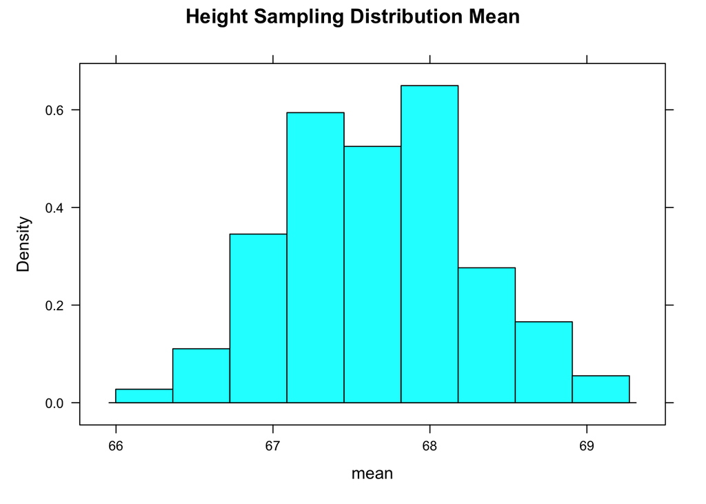

```r
#history
histogram(~ mean, data = survivors199$height_mean, main = "Height Sampling Distribution Mean")
```

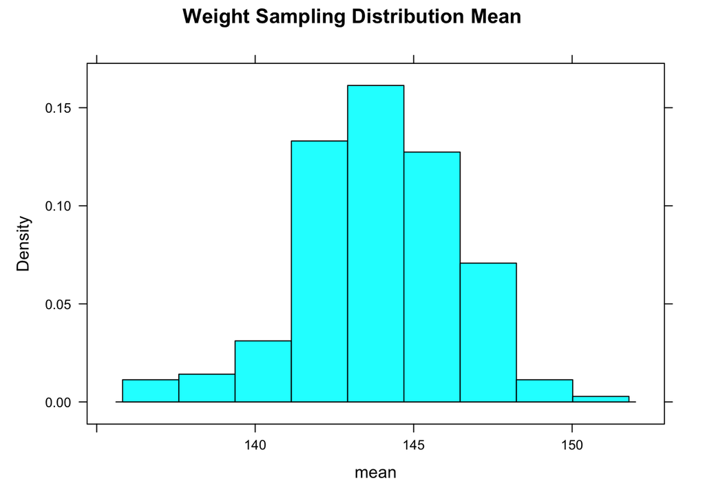

```r
#weight
histogram(~ mean, data = survivors199$weight_mean, main = "Weight Sampling Distribution Mean")
```

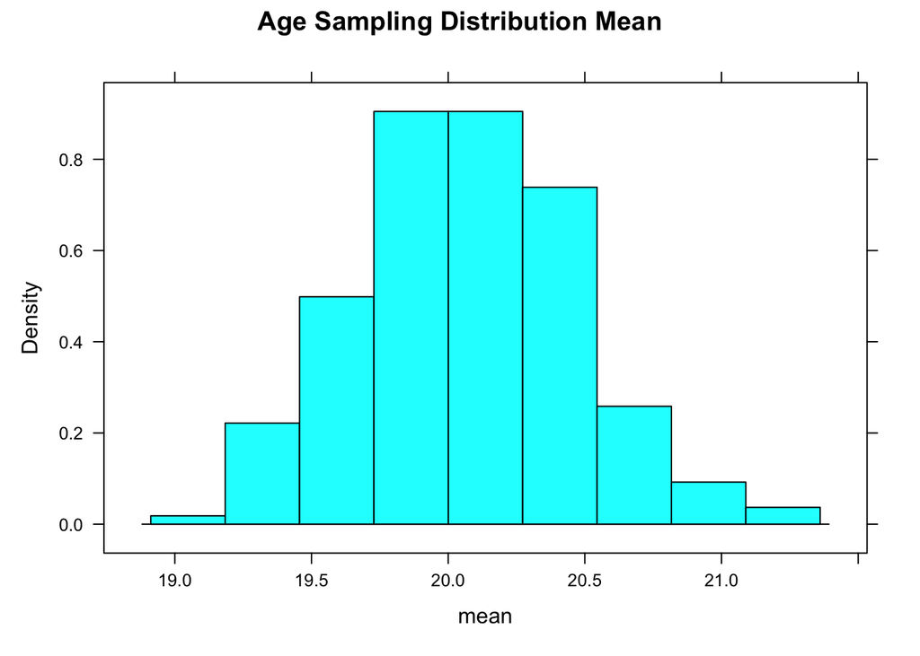

```r
#age
histogram(~ mean, data = survivors199$age_mean, main = "Age Sampling Distribution Mean")
```

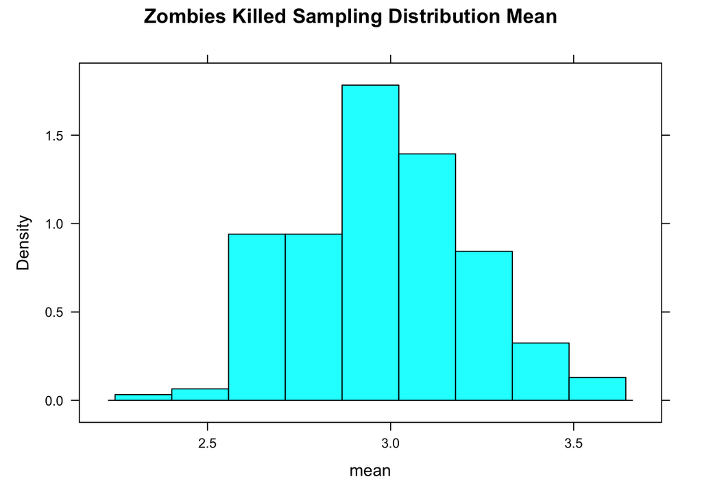

```r
#zombies killed
histogram(~ mean, data = survivors199$zombieK_mean, main = "Zombies Killed Sampling Distribution Mean")
```

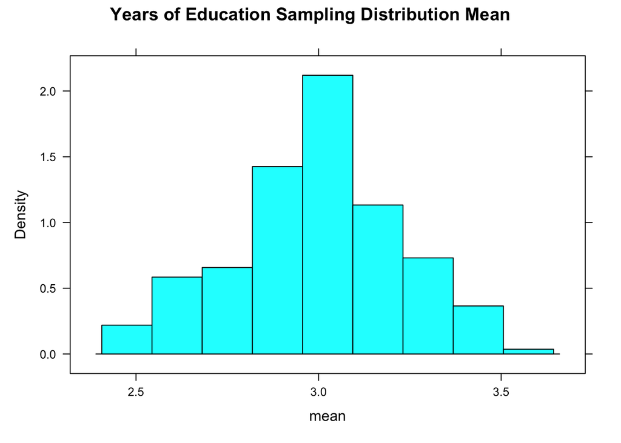

```r
#years of education
histogram(~ mean, data = survivors199$edu_mean, main = "Years of Education Sampling Distribution Mean")
```

**Note: i would use cowplot to put these all together, but cowplot is very slow**

[C] Are they normally distributed? What about for those variables that you concluded were not originally drawn from a normal distribution? **A: Because we are plotting the distribution of means, the quantitative variables that are not linear (zombies killed and years of education) have been linearized as now they are plotted respectively as their mean number of occurrences.**

[D] How do the two 95% CIs you estimated compare to one another (i.e., the CI based on one sample and the corresponding sample standard deviation versus the CI based on simulation where you created a sampling distribution across 200 samples)?

```r
#notes from Tony 03/03/22: finally, your last comparison didn't run correctly for me.

survivors50CI <- survivors50[ , c(5,6)] #indexing to re-orient table so compatible with zCI table
survivors50CI
```

```
## # A tibble: 5 × 2
##   s1_lower_ci s1_upper_ci
##         <dbl>       <dbl>
## 1       66.9        67.7
## 2      141.        145.
## 3       19.8        20.4
## 4        2.90        3.26
## 5        2.89        3.19
```

```r
comparison_4<- add_column(zCI, survivors50CI)
comparison_4
```

```
## # A tibble: 5 × 4
##   `Lower CI` `Upper CI` s1_lower_ci s1_upper_ci
##        <dbl>      <dbl>       <dbl>       <dbl>
## 1     134.       136.         66.9        67.7
## 2     283.       292.        141.        145.
## 3      39.3       40.9        19.8        20.4
## 4       5.59       6.53        2.90        3.26
## 5       5.58       6.48        2.89        3.19
```